# hw-3 code

First i will load library and clean memory

```r
#Load Libraries
rm(list = ls()) # clean memory
library(tidyverse)
library(readxl)
library(ggplot2)
library(qicharts2)
library(scales)
```

I will now load my data

```r
#Load Data


file_path <- "C:/Users/lgianetti/OneDrive - City of Cambridge/DACSS Program/690V_data_viz/hw-3/ncesdata_MASS_202425.xlsx"

my_data <- read_excel(path = file_path,
    skip = 11)
```

I will do a quick look at the data

```r
#Look at Data
str(my_data, width = 70,strict.width='cut')
```

```
tibble [1,824 × 26] (S3: tbl_df/tbl/data.frame)
 $ NCES School ID       : chr [1:1824] "250732002639" "250711001062"..
 $ State School ID      : chr [1:1824] "MA-0170-01700045" "MA-0163-"..
 $ NCES District ID     : chr [1:1824] "2507320" "2507110" "2508610"..
 $ State District ID    : chr [1:1824] "MA-0170" "MA-0163" "MA-0207"..
 $ Low Grade            : chr [1:1824] "06" "KG" "KG" "04" ...
 $ High Grade           : chr [1:1824] "08" "05" "05" "05" ...
 $ School Name          : chr [1:1824] "1 LT Charles W. Whitcomb Sc"..
 $ District             : chr [1:1824] "Marlborough" "Lynn" "Newton"..
 $ County Name          : chr [1:1824] "Middlesex County" "Essex Co"..
 $ Street Address       : chr [1:1824] "25 Union Street" "34 Hood S"..
 $ City                 : chr [1:1824] "Marlborough" "Lynn" "Waban""..
 $ State                : chr [1:1824] "MA" "MA" "MA" "MA" ...
 $ ZIP                  : chr [1:1824] "01752" "01905" "02468" "015"..
 $ ZIP 4-digit          : chr [1:1824] NA NA NA NA ...
 $ Phone                : chr [1:1824] "(508)460-3502" "(781)477-73"..
 $ Locale Code          : chr [1:1824] "21" "21" "13" "21" ...
 $ Locale               : chr [1:1824] "Suburban, Large" "Suburban,"..
 $ Charter              : chr [1:1824] "No" "No" "No" "No" ...
 $ Students             : chr [1:1824] "965.00000" "488.00000" "383"..
 $ Teachers             : chr [1:1824] "103.36000" "41.67000" "38.1"..
 $ Student Teacher Ratio: chr [1:1824] "9.3400000" "11.7100000" "10"..
 $ Free Lunch           : chr [1:1824] "–" "–" "–" "†" ...
 $ Reduced Lunch        : chr [1:1824] "–" "–" "–" "†" ...
 $ Directly Certified   : chr [1:1824] "600.00000" "404.00000" "30."..
 $ Type                 : chr [1:1824] "Regular" "Regular" "Regular"..
 $ Status               : chr [1:1824] "Open" "Open" "Open" "Open" ...
```

Now I will clean the data by correcting the data types and checking for missing values and outliers. I will also convert the appropriate columns to factors and numeric types as needed.

```r
#Clean Data
my_data$`Low Grade` <- factor(my_data$`Low Grade`, ordered = TRUE)
my_data$`High Grade` <- factor(my_data$`High Grade`, ordered = TRUE)
my_data$`Locale Code` <- factor(my_data$`Locale Code`)
my_data$`Locale` <- factor(my_data$`Locale`)
my_data$`Charter` <- factor(my_data$`Charter`)
my_data$`Type` <- factor(my_data$`Type`)
my_data$`Status` <- factor(my_data$`Status`)
my_data$`Students` <- as.numeric(my_data$`Students`)
my_data$`Teachers` <- as.numeric(my_data$`Teachers`)
my_data$`Student Teacher Ratio` <- as.numeric(my_data$`Student Teacher Ratio`)
my_data$`Directly Certified` <- as.numeric(my_data$`Directly Certified`)
my_data$`County Name` <- factor(my_data$`County Name`)


str(my_data, width = 70,strict.width='cut')
```

```
tibble [1,824 × 26] (S3: tbl_df/tbl/data.frame)
 $ NCES School ID       : chr [1:1824] "250732002639" "250711001062"..
 $ State School ID      : chr [1:1824] "MA-0170-01700045" "MA-0163-"..
 $ NCES District ID     : chr [1:1824] "2507320" "2507110" "2508610"..
 $ State District ID    : chr [1:1824] "MA-0170" "MA-0163" "MA-0207"..
 $ Low Grade            : Ord.factor w/ 14 levels "01"<"02"<"03"<..:..
 $ High Grade           : Ord.factor w/ 14 levels "01"<"02"<"03"<..:..
 $ School Name          : chr [1:1824] "1 LT Charles W. Whitcomb Sc"..
 $ District             : chr [1:1824] "Marlborough" "Lynn" "Newton"..
 $ County Name          : Factor w/ 14 levels "Barnstable County",....
 $ Street Address       : chr [1:1824] "25 Union Street" "34 Hood S"..
 $ City                 : chr [1:1824] "Marlborough" "Lynn" "Waban""..
 $ State                : chr [1:1824] "MA" "MA" "MA" "MA" ...
 $ ZIP                  : chr [1:1824] "01752" "01905" "02468" "015"..
 $ ZIP 4-digit          : chr [1:1824] NA NA NA NA ...
 $ Phone                : chr [1:1824] "(508)460-3502" "(781)477-73"..
 $ Locale Code          : Factor w/ 10 levels "11","12","13",..: 4 4..
 $ Locale               : Factor w/ 10 levels "City, Large",..: 6 6 ..
 $ Charter              : Factor w/ 2 levels "No","Yes": 1 1 1 1 1 1..
 $ Students             : num [1:1824] 965 488 383 0 658 ...
 $ Teachers             : num [1:1824] 103.4 41.7 38.1 0 60.8 ...
 $ Student Teacher Ratio: num [1:1824] 9.34 11.71 10.05 NA 10.83 ...
 $ Free Lunch           : chr [1:1824] "–" "–" "–" "†" ...
 $ Reduced Lunch        : chr [1:1824] "–" "–" "–" "†" ...
 $ Directly Certified   : num [1:1824] 600 404 30 NA 418 150 25 28 8..
 $ Type                 : Factor w/ 4 levels "Other/Alternative",..:..
 $ Status               : Factor w/ 3 levels "Future","New",..: 3 3 ..
```

```r
summary(my_data) # check for missing values and outliers
```

```
 NCES School ID     State School ID    NCES District ID
 Length:1824        Length:1824        Length:1824
 Class :character   Class :character   Class :character
 Mode  :character   Mode  :character   Mode  :character




 State District ID    Low Grade     High Grade  School Name
 Length:1824        PK     :566   05     :498   Length:1824
 Class :character   KG     :438   12     :414   Class :character
 Mode  :character   09     :268   08     :361   Mode  :character
                    06     :212   06     :175
                    05     : 83   04     :134
                    07     : 76   PK     : 73
                    (Other):181   (Other):169
   District                   County Name  Street Address
 Length:1824        Middlesex County:382   Length:1824
 Class :character   Worcester County:256   Class :character
 Mode  :character   Essex County    :214   Mode  :character
                    Norfolk County  :189
                    Hampden County  :162
                    Suffolk County  :154
                    (Other)         :467
     City              State               ZIP
 Length:1824        Length:1824        Length:1824
 Class :character   Class :character   Class :character
 Mode  :character   Mode  :character   Mode  :character




 ZIP 4-digit           Phone            Locale Code
 Length:1824        Length:1824        21     :1121
 Class :character   Class :character   41     : 170
 Mode  :character   Mode  :character   12     : 143
                                       11     : 127
                                       13     :  85
                                       22     :  71
                                       (Other): 107
```

[output cut: 9 more lines]

```
 Min.   :   1.57       Length:1824        Length:1824
 1st Qu.:  10.36       Class :character   Class :character
 Median :  11.79       Mode  :character   Mode  :character
 Mean   :  14.45
 3rd Qu.:  13.27
 Max.   :2500.00
 NA's   :10
 Directly Certified                Type         Status
 Min.   :   3.0     Other/Alternative:  29   Future:   1
 1st Qu.:  68.0     Regular          :1744   New   :  11
 Median : 140.0     Special Education:  15   Open  :1812
 Mean   : 212.0     Vocational       :  36
 3rd Qu.: 269.5
 Max.   :2834.0
 NA's   :21
```

Now I will start to explore the data by creating some visualizations. I will create a bar plot to show the distribution of schools by County.

```r
# Total values
TotalValues=table(my_data$'County Name',
                 useNA = "ifany") #include all values!
TotalValues
```

```
Barnstable County  Berkshire County    Bristol County      Dukes County
               49                48               141                 8
     Essex County   Franklin County    Hampden County  Hampshire County
              214                35               162                44
 Middlesex County  Nantucket County    Norfolk County   Plymouth County
              382                 4               189               138
   Suffolk County  Worcester County
              154               256
```

```r
TotalPercent = prop.table(TotalValues)*100
```

```r
# Create a data frame for plotting
CountyTable=as.data.frame(TotalValues)

names(CountyTable)=c("County","Count")

CountyTable$Percent=as.vector(TotalPercent)

CountyTable
```

| County | Count | Percent |
| --- | --- | --- |
| Barnstable County | 49 | 2.6864035 |
| Berkshire County | 48 | 2.6315789 |
| Bristol County | 141 | 7.7302632 |
| Dukes County | 8 | 0.4385965 |
| Essex County | 214 | 11.7324561 |
| Franklin County | 35 | 1.9188596 |
| Hampden County | 162 | 8.8815789 |
| Hampshire County | 44 | 2.4122807 |
| Middlesex County | 382 | 20.9429825 |
| Nantucket County | 4 | 0.2192982 |

[output cut: 4 more lines]

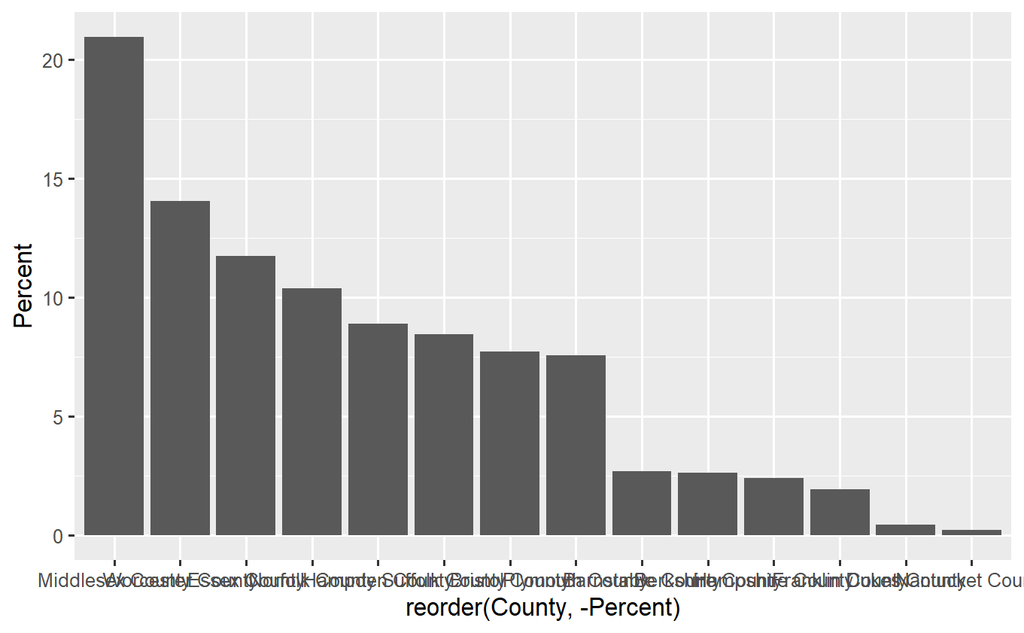

```r
# Create a bar plot
base = ggplot(CountyTable,
              aes(x=reorder(County, -Percent),
                  y=Percent))

base + geom_bar(stat="identity")
```

```r
#impute outliers with mean value for the county. Impute any student teacher ratio over 100 with the mean value for the county
my_data <- my_data %>%
  group_by(`County Name`) %>%
  mutate(`Student Teacher Ratio` = ifelse(`Student Teacher Ratio` > 100,
                                         mean(`Student Teacher Ratio`, na.rm = TRUE),
                                           `Student Teacher Ratio`))
```

```r
# Calculate average student teacher ratio per county
AvgStudentTeacherRatioCounty = my_data |>
  group_by(`County Name`) |>
  summarise(AvgRatio = mean(`Student Teacher Ratio`, na.rm = TRUE))
AvgStudentTeacherRatioCounty
```

| County Name | AvgRatio |
| --- | --- |
| Barnstable County | 10.205510 |
| Berkshire County | 9.802083 |
| Bristol County | 12.855532 |
| Dukes County | 7.501429 |
| Essex County | 11.702009 |
| Franklin County | 9.904000 |
| Hampden County | 11.793033 |
| Hampshire County | 10.597727 |
| Middlesex County | 11.729503 |
| Nantucket County | 9.980000 |

[output cut: 4 more lines]

```r
#add  average student teacher ratio by county to the County Table
CountyTable = CountyTable |>
  left_join(AvgStudentTeacherRatioCounty, by = c("County" = "County Name"))
```

calculate the aver and median student teacher ratio for each county. Then plot these. Then add reference line for mean or median. then show how far above or below they are.

```r
# Calculate a single average and median student teacher ratio use as a refernce line in the plot
OverallAvgStudentTeacherRatio = mean(my_data$`Student Teacher Ratio`, na.rm = TRUE)
OverallMedianStudentTeacherRatio = median(my_data$`Student Teacher Ratio`, na.rm = TRUE)

OverallAvgStudentTeacherRatio
```

```
[1] 11.95753
```

```r
OverallMedianStudentTeacherRatio
```

```
[1] 11.79
```

```r
#add overall average to County Table
CountyTable$OverallAvg = OverallAvgStudentTeacherRatio

#calculate the difference between the average student teacher ratio for each county and the overall average
CountyTable$DifferenceFromOverallAvg = CountyTable$AvgRatio - CountyTable$OverallAvg

#only keep the first word in the County variable
CountyTable$County = word(CountyTable$County, 1)
```

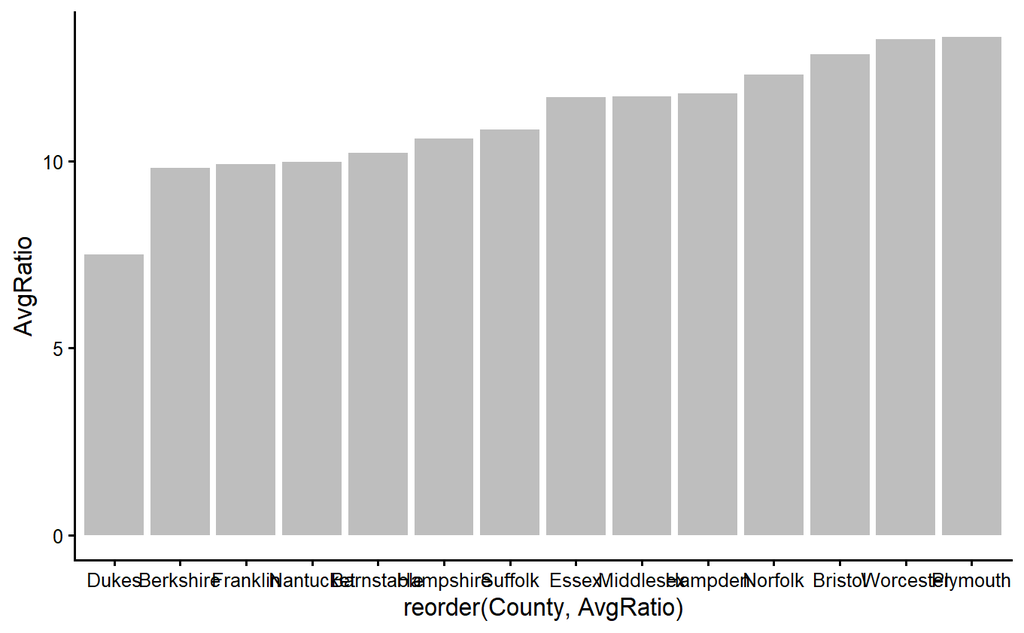

```r
# Create a bar plot of average student teacher ratio by county
base_st = ggplot(CountyTable,
              aes(x=reorder(County, AvgRatio),
                  y=AvgRatio))

base_st = base_st + theme_classic()

plot1 = base_st +
  geom_col(fill = "gray")

plot1
```

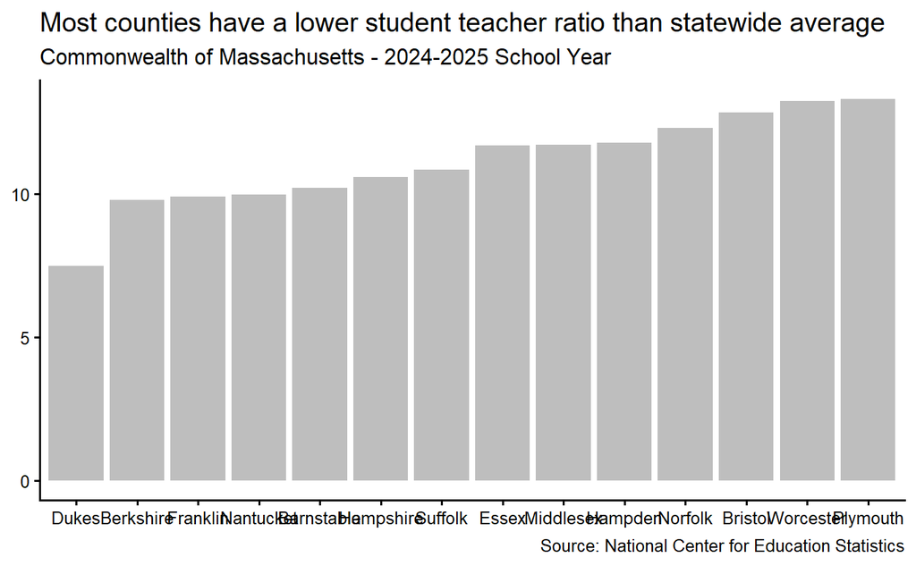

```r
titleText='Most counties have a lower student teacher ratio than statewide average'
sub_titleText='Commonwealth of Massachusetts - 2024-2025 School Year'
sourceText='Source: National Center for Education Statistics'

plot2 = plot1 + labs(title=titleText,
                     subtitle=sub_titleText,
                     x =NULL,
                     y = NULL,
                     caption = sourceText)

plot2
```

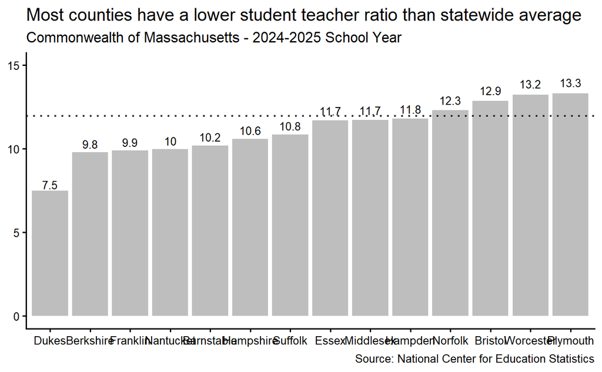

```r
#adding the average student teacher ratio for the state as a reference line

plot3 = plot2 + geom_hline( yintercept = 11.95753,
                            linetype = "dotted",
                            linewidth = .7,
                            alpha = 0.8,) +
  scale_y_continuous(breaks=c(0,5,10, 15),
                                 limits = c(0, 15)
                          ) +
  geom_text(aes(label=round(AvgRatio,1)),
            position = position_stack(vjust = 1.05),
            size = 3)

plot3
```

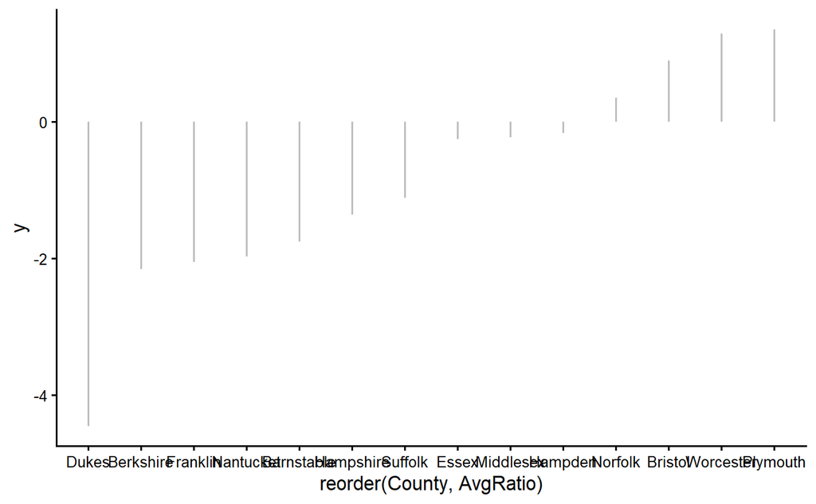

```r
base_st = ggplot(CountyTable,
              aes(x=reorder(County, AvgRatio),
                  y=DifferenceFromOverallAvg))

base_st = base_st + theme_classic()
#creating a lollipop plot to show the difference between the average student teacher ratio for each county and the overall average

lolliplot1 = base_st + geom_segment(aes(y=0,
                                   x= reorder(County, AvgRatio),
                                   yend= DifferenceFromOverallAvg,
                                   xend= reorder(County, AvgRatio)),
                             color="gray", size=0.5)
lolliplot1
```

```r
#adding Postitive/Negative Color
CountyTable$StateAverage=ifelse(CountyTable$DifferenceFromOverallAvg>0,"Higher","Lower") #lower, so negative/no, is good in this case
CountyTable
```

| County | Count | Percent | AvgRatio | OverallAvg | DifferenceFromOverallAvg | StateAverage |
| --- | --- | --- | --- | --- | --- | --- |
| Barnstable | 49 | 2.6864035 | 10.205510 | 11.95753 | -1.7520192 | Lower |
| Berkshire | 48 | 2.6315789 | 9.802083 | 11.95753 | -2.1554461 | Lower |
| Bristol | 141 | 7.7302632 | 12.855532 | 11.95753 | 0.8980025 | Higher |
| Dukes | 8 | 0.4385965 | 7.501429 | 11.95753 | -4.4561009 | Lower |
| Essex | 214 | 11.7324561 | 11.702009 | 11.95753 | -0.2555201 | Lower |
| Franklin | 35 | 1.9188596 | 9.904000 | 11.95753 | -2.0535294 | Lower |
| Hampden | 162 | 8.8815789 | 11.793033 | 11.95753 | -0.1644960 | Lower |
| Hampshire | 44 | 2.4122807 | 10.597727 | 11.95753 | -1.3598022 | Lower |
| Middlesex | 382 | 20.9429825 | 11.729503 | 11.95753 | -0.2280268 | Lower |
| Nantucket | 4 | 0.2192982 | 9.980000 | 11.95753 | -1.9775294 | Lower |

[output cut: 4 more lines]

```r
base_st = ggplot(CountyTable,
              aes(x=reorder(County, AvgRatio),
                  y=DifferenceFromOverallAvg,
                  color=StateAverage,
                  label=round(DifferenceFromOverallAvg,2))
              )

base_st = base_st + theme_classic()

lolliplot1 = base_st + geom_segment(aes(y=0,
                                   x= reorder(County, AvgRatio),
                                   yend= DifferenceFromOverallAvg,
                                   xend= reorder(County, AvgRatio)),
                             color="gray", size=0.5)

lolliplot2= lolliplot1 +
  geom_point(size=2) +
  geom_text(nudge_x = .4,
            size=2.4,
            show.legend = FALSE)

#add horizontal line at 0 to show the state average and labels
lolliplot2 = lolliplot2 + geom_hline(yintercept = 0,
                        linewidth = .7,
                        alpha = 0.8) +
  scale_color_manual(values = c("Higher" = "red", "Lower" = "black")) +
  labs(title="Most counties in Massachusetts have a lower student teacher ratio \nthan the statewide average of 11.96.",
       subtitle="2024-2025 School Year",
       x=NULL,
       y="Difference from State Average Student Teacher Ratio",
       caption="Source: National Center for Education Statistics \n10 records removed for lack of data and 2 outliers imputed with county mean") +
  theme(legend.position = "none")
```

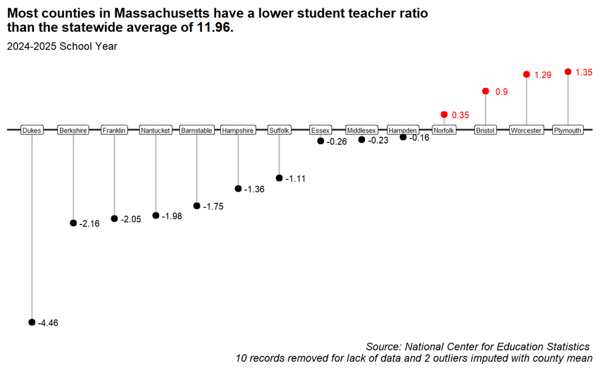

```r
#now i will finish the plot getting rid of elements and moving the county label

lolliplot3 = lolliplot2 + theme(axis.ticks.y = element_blank(),
                                axis.title.y = element_blank(),
                                axis.line.y = element_blank(),
                                axis.text.y = element_blank(),
                                axis.ticks.x = element_blank(),
                                axis.title.x = element_blank(),
                                axis.line.x = element_blank()
                                )


lolliplot3 = lolliplot3 + geom_label(aes(label=County),
                                      color ='black ',
                                      size =1.75,
                                      y=0,
                                      show.legend = FALSE ) +
             theme(axis.text.x = element_blank(),
                   plot.title = element_text(face = "bold", size = 10),
                   plot.subtitle = element_text(size = 8),
                   plot.caption = element_text(face = "italic", size = 8)
                   )

lolliplot3
```

```r
charplot <-lolliplot3
```

```r
#add total number of students per county
TotalStudents = my_data |>
  group_by(`County Name`) |>
  summarise(TotalStudents = sum(Students, na.rm = TRUE))

#change county name to only the first word in the TotalStudents table and remove county name variable
TotalStudents$County = word(TotalStudents$`County Name`, 1)
TotalStudents = TotalStudents |>
  select(-`County Name`)

#join total students to the CountyTable by County
CountyTable = CountyTable |>
  left_join(TotalStudents, by = c("County" = "County"))
```

# Numerical Variable

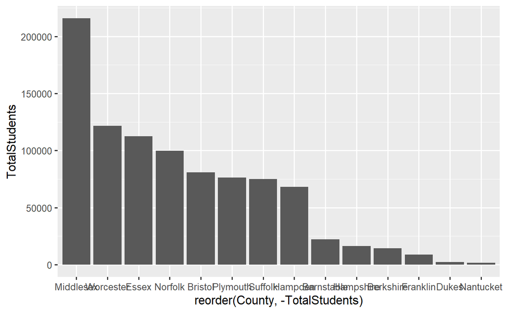

```r
#I am going to create a pareto plot showing the total distribution of students across counties


Base_pareto = ggplot(CountyTable,
              aes(x=reorder(County, -TotalStudents),
                  y=TotalStudents))
paretoplot = Base_pareto + geom_col()

paretoplot
```

```r
NA
NA
NA
```

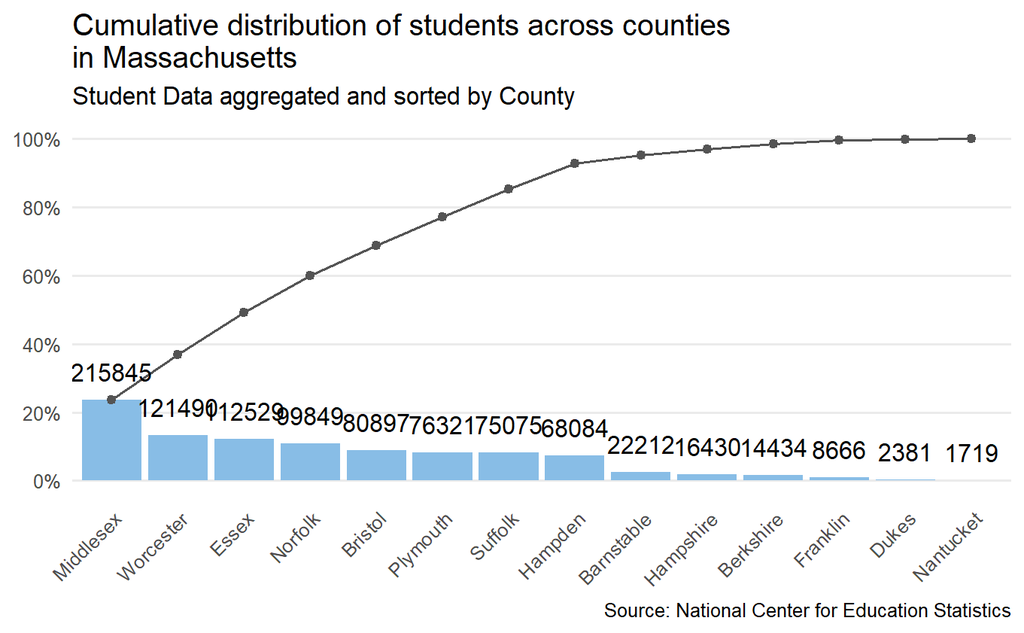

```r
# prepare the data for 'qicharts2'

x <- rep(CountyTable$County, CountyTable$TotalStudents)


paretoplot2 = paretochart(x,x.angle = 45)

paretoplot2 +
    labs(title='Cumulative distribution of students across counties \nin Massachusetts',
       subtitle = 'Student Data aggregated and sorted by County',
       caption="Source: National Center for Education Statistics")
```

```r
NA
NA
NA
```

I cannot really modify the base chart, so i will recreate with ggplot to have more control over the design

```r
# sort data and calculate cumulative percentage for the pareto plot
CountyTable_plot <- CountyTable %>%
  arrange(desc(TotalStudents)) %>%
  mutate(
    County = factor(County, levels = County),
    percent_students = TotalStudents / sum(TotalStudents),
    cumulative_pct = cumsum(TotalStudents) / sum(TotalStudents),
    label = comma(TotalStudents)
  )
```

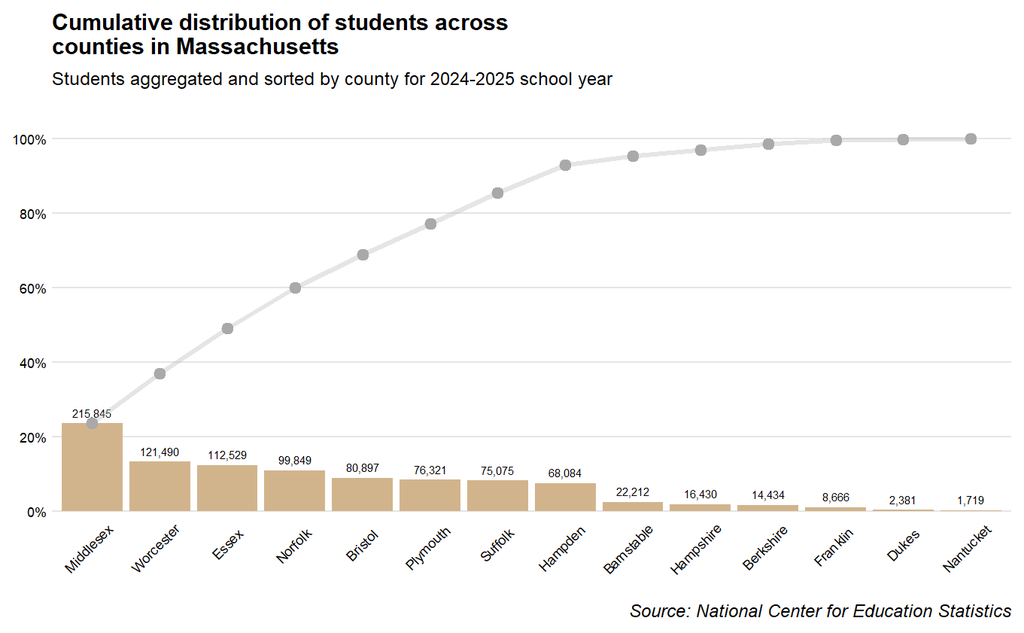

```r
# Create Pareto-style chart

numplot = ggplot(CountyTable_plot, aes(x = County)) +
  geom_col(aes(y = percent_students), fill = "tan") +
  geom_text(
    aes(y = percent_students, label = label),
    vjust = -0.7,
    size = 1.8
  ) +
  geom_line(
    aes(y = cumulative_pct, group = 1),
    color = "gray",
    linewidth = 1,
    alpha = 0.4
  ) +
  geom_point(
    aes(y = cumulative_pct),
    color = "darkgray",
    size = 2
  ) +
  scale_y_continuous(
    labels = percent,
    limits = c(0, 1.05),
    breaks = seq(0, 1, by = 0.2)
  ) +

  labs(
    title = "Cumulative distribution of students across \ncounties in Massachusetts",
    subtitle = "Students aggregated and sorted by county for 2024-2025 school year",
    x = NULL,
    y=NULL,
    caption = "Source: National Center for Education Statistics"
  ) +
  theme_classic() +
  theme(
    axis.text.x = element_text(angle = 45, hjust = 0.7, size = 6),
    axis.text.y = element_text(size = 6),
    plot.title = element_text(face = "bold", size = 10),
    plot.subtitle = element_text(size = 8),
    plot.caption = element_text(face = "italic", size = 8),
    axis.line.x = element_blank(),
    axis.line.y = element_blank(),
    axis.ticks = element_blank(),
    panel.grid.major.y = element_line(color = "grey90", linewidth = 0.4),
    panel.grid.minor.y = element_blank(),
    panel.grid.major.x = element_blank()
  )
numplot
```

```r
saveRDS(charplot, file = "plot1.rds")
saveRDS(numplot, file = "plot2.rds")
```